# Air Quality and Lung Health: A Complete Data Analysis in R

Data Analysis Bootcamp, Batch 5, 2026

# 1 About this analysis

**The story.** A city is worried about air pollution. Researchers surveyed **adults living in four zones** (Industrial, Traffic Hub, Residential and Park). For every person they recorded the dust level where the person lives (**PM2.5**), lifestyle, body measurements and lung health.

**The plan.** We go through the data the way a real analyst does:

1. Load the data and look at it
2. Fix the data types
3. Create helpful new variables
4. Check data quality (missing values, duplicates, impossible values, outliers)
5. Describe each variable on its own
6. Check the shape of the data (normal or skewed?)
7. Compare groups, test links between categories, and measure relationships between numbers
8. Build models that combine several variables
9. Summarise the findings

**How to read each test.** Every test starts with a *null hypothesis* (H0: “nothing is going on”) and an *alternative hypothesis* (H1: “something is going on”). We use a significance level of **0.05**. If p < 0.05 we reject H0 and call the result *significant*. A small p-value tells us the result is unlikely to be chance. It does **not** tell us the result is large or important, so we also report effect sizes.

# 2 Load the data and take a first look

```r
d <- read.csv(data_file, stringsAsFactors = FALSE)   # read the CSV file
d_raw <- d                                           # keep an untouched copy to compare later

dim(d)          # rows and columns
```

```
## [1] 1200   15
```

```r
str(d)          # structure: the type of each variable
```

```
## 'data.frame':    1200 obs. of  15 variables:
##  $ Participant_ID     : int  5001 5002 5003 5004 5005 5006 5007 5008 5009 5010 ...
##  $ Survey_Date        : chr  "2026-03-20" "2026-01-29" "2026-03-13" "2026-03-31" ...
##  $ Zone               : chr  "Traffic_Hub" "Traffic_Hub" "Residential" "Industrial" ...
##  $ Age                : int  40 43 28 43 40 33 41 36 34 52 ...
##  $ Sex                : chr  "Female" "Male" "Female" "Male" ...
##  $ Smoker             : chr  "No" "No" "No" "No" ...
##  $ Exercise_Level     : chr  "Low" "Moderate" "Moderate" "Moderate" ...
##  $ BMI                : num  29.3 21 25.3 23.1 28.7 20.3 31.6 20.7 17.9 21.2 ...
##  $ Sleep_Hours        : num  5.5 6.5 6.7 5.5 6 6.2 5.8 7.9 7 9.1 ...
##  $ Mask_Use           : chr  "Sometimes" "Sometimes" "Always" "Never" ...
##  $ PM25               : num  219.8 162.9 122 196.5 86.2 ...
##  $ Cough_Days         : int  10 2 3 8 7 3 3 5 5 0 ...
##  $ Resting_HR         : int  68 62 72 85 66 88 65 70 89 60 ...
##  $ Lung_Capacity_L    : num  2.53 2.99 3.06 3 3.6 3.33 3.59 3.89 2.62 3.46 ...
##  $ Respiratory_Illness: chr  "No" "No" "No" "No" ...
```

```r
head(d)         # first 6 rows
```

```
##   Participant_ID Survey_Date        Zone Age    Sex Smoker Exercise_Level  BMI
## 1           5001  2026-03-20 Traffic_Hub  40 Female     No            Low 29.3
## 2           5002  2026-01-29 Traffic_Hub  43   Male     No       Moderate 21.0
## 3           5003  2026-03-13 Residential  28 Female     No       Moderate 25.3
## 4           5004  2026-03-31  Industrial  43   Male     No       Moderate 23.1
## 5           5005  2026-01-24 Residential  40   Male    Yes       Moderate 28.7
## 6           5006  2026-03-14        Park  33   Male    Yes       Moderate 20.3
##   Sleep_Hours  Mask_Use  PM25 Cough_Days Resting_HR Lung_Capacity_L
## 1         5.5 Sometimes 219.8         10         68            2.53
## 2         6.5 Sometimes 162.9          2         62            2.99
## 3         6.7    Always 122.0          3         72            3.06
## 4         5.5     Never 196.5          8         85            3.00
## 5         6.0     Never  86.2          7         66            3.60
## 6         6.2     Never  51.2          3         88            3.33
##   Respiratory_Illness
## 1                  No
## 2                  No
## 3                  No
## 4                  No
## 5                 Yes
## 6                  No
```

The file has **1200 people (rows)** and **15 variables (columns)**. Notice that most text columns are stored as `chr` (character) and the numbers are stored as `num` or `int`. R does not know which text columns are *categories*, which one is a *date*, or which number is only an *ID*. We fix that next.

# 3 Fix the data types

Choosing the right data type matters because R treats each type differently. For example, you can average a number but not a category, and a factor with ordered levels sorts correctly in tables and plots.

| Variable | Now | Should be | Why |
| --- | --- | --- | --- |
| Participant_ID | number | text (character) | It is a label. We never want to average an ID. |
| Survey_Date | text | Date | So R can sort dates and extract months. |
| Zone, Sex, Smoker, Respiratory_Illness | text | factor (category) | They are groups. |
| Exercise_Level, Mask_Use | text | **ordered** factor | Low < Moderate < High, and Never < Sometimes < Always. |
| Age, Cough_Days, Resting_HR | decimal number | integer | They are whole numbers (counts or years). |
| BMI, Sleep_Hours, PM25, Lung_Capacity_L | decimal number | stays numeric | They are measurements. |

```r
d$Participant_ID <- as.character(d$Participant_ID)       # an ID is a label, not a number
d$Survey_Date    <- as.Date(d$Survey_Date)               # text -> date

# categories: we choose the order of the levels ourselves
d$Zone <- factor(d$Zone, levels = c("Park", "Residential", "Traffic_Hub", "Industrial"))
d$Sex  <- factor(d$Sex,  levels = c("Female", "Male"))
d$Smoker <- factor(d$Smoker, levels = c("No", "Yes"))
d$Respiratory_Illness <- factor(d$Respiratory_Illness, levels = c("No", "Yes"))

# ordered categories: ordered = TRUE tells R that the order has a meaning
d$Exercise_Level <- factor(d$Exercise_Level, levels = c("Low", "Moderate", "High"), ordered = TRUE)
d$Mask_Use       <- factor(d$Mask_Use, levels = c("Never", "Sometimes", "Always"), ordered = TRUE)

# whole numbers
d$Age        <- as.integer(d$Age)
d$Cough_Days <- as.integer(d$Cough_Days)
d$Resting_HR <- as.integer(d$Resting_HR)

str(d)
```

```
## 'data.frame':    1200 obs. of  15 variables:
##  $ Participant_ID     : chr  "5001" "5002" "5003" "5004" ...
##  $ Survey_Date        : Date, format: "2026-03-20" "2026-01-29" ...
##  $ Zone               : Factor w/ 4 levels "Park","Residential",..: 3 3 2 4 2 1 1 2 3 3 ...
##  $ Age                : int  40 43 28 43 40 33 41 36 34 52 ...
##  $ Sex                : Factor w/ 2 levels "Female","Male": 1 2 1 2 2 2 2 2 1 2 ...
##  $ Smoker             : Factor w/ 2 levels "No","Yes": 1 1 1 1 2 2 1 1 1 1 ...
##  $ Exercise_Level     : Ord.factor w/ 3 levels "Low"<"Moderate"<..: 1 2 2 2 2 2 2 3 1 3 ...
##  $ BMI                : num  29.3 21 25.3 23.1 28.7 20.3 31.6 20.7 17.9 21.2 ...
##  $ Sleep_Hours        : num  5.5 6.5 6.7 5.5 6 6.2 5.8 7.9 7 9.1 ...
##  $ Mask_Use           : Ord.factor w/ 3 levels "Never"<"Sometimes"<..: 2 2 3 1 1 1 1 1 2 1 ...
##  $ PM25               : num  219.8 162.9 122 196.5 86.2 ...
##  $ Cough_Days         : int  10 2 3 8 7 3 3 5 5 0 ...
##  $ Resting_HR         : int  68 62 72 85 66 88 65 70 89 60 ...
##  $ Lung_Capacity_L    : num  2.53 2.99 3.06 3 3.6 3.33 3.59 3.89 2.62 3.46 ...
##  $ Respiratory_Illness: Factor w/ 2 levels "No","Yes": 1 1 1 1 2 1 1 1 1 1 ...
```

A before-and-after check of all the types:

```r
type_check <- data.frame(
  Variable = names(d),
  Before   = sapply(d_raw, function(x) class(x)[1]),
  After    = sapply(d,     function(x) paste(class(x), collapse = " / ")),
  row.names = NULL)
knitr::kable(type_check)
```

| Variable | Before | After |
| --- | --- | --- |
| Participant_ID | integer | character |
| Survey_Date | character | Date |
| Zone | character | factor |
| Age | integer | integer |
| Sex | character | factor |
| Smoker | character | factor |
| Exercise_Level | character | ordered / factor |
| BMI | numeric | numeric |
| Sleep_Hours | numeric | numeric |
| Mask_Use | character | ordered / factor |
| PM25 | numeric | numeric |
| Cough_Days | integer | integer |
| Resting_HR | integer | integer |
| Lung_Capacity_L | numeric | numeric |
| Respiratory_Illness | character | factor |

# 4 Create new variables

Sometimes a number is easier to understand in groups. We create four helper variables and keep the original numbers as well.

```r
# Age groups
d$Age_Group <- cut(d$Age, breaks = c(17, 29, 39, 49, 65),
                   labels = c("18-29", "30-39", "40-49", "50-65"))

# BMI categories (standard cut-offs)
d$BMI_Category <- cut(d$BMI, breaks = c(0, 18.5, 25, 30, Inf), right = FALSE,
                      labels = c("Underweight", "Normal", "Overweight", "Obese"))

# Dust level groups (our own cut-offs, in micrograms per cubic metre)
d$PM25_Level <- cut(d$PM25, breaks = c(0, 50, 100, 150, Inf), right = FALSE,
                    labels = c("Low (<50)", "Moderate (50-99)", "High (100-149)", "Very high (150+)"))

# Month of the survey (numbers 1-4 turned into names, so it works on any computer language)
d$Month <- factor(as.integer(format(d$Survey_Date, "%m")), levels = 1:4,
                  labels = c("Jan", "Feb", "Mar", "Apr"))

knitr::kable(head(d[, c("Age", "Age_Group", "BMI", "BMI_Category", "PM25", "PM25_Level",
                        "Survey_Date", "Month")]))
```

| Age | Age_Group | BMI | BMI_Category | PM25 | PM25_Level | Survey_Date | Month |
| --- | --- | --- | --- | --- | --- | --- | --- |
| 40 | 40-49 | 29.3 | Overweight | 219.8 | Very high (150+) | 2026-03-20 | Mar |
| 43 | 40-49 | 21.0 | Normal | 162.9 | Very high (150+) | 2026-01-29 | Jan |
| 28 | 18-29 | 25.3 | Overweight | 122.0 | High (100-149) | 2026-03-13 | Mar |
| 43 | 40-49 | 23.1 | Normal | 196.5 | Very high (150+) | 2026-03-31 | Mar |
| 40 | 40-49 | 28.7 | Overweight | 86.2 | Moderate (50-99) | 2026-01-24 | Jan |
| 33 | 30-39 | 20.3 | Normal | 51.2 | Moderate (50-99) | 2026-03-14 | Mar |

# 5 Data quality checks

## 5.1 Missing values

```r
na_count <- colSums(is.na(d))
na_table <- data.frame(Variable = names(na_count), Missing = na_count,
                       Percent = round(100 * na_count / nrow(d), 1), row.names = NULL)
knitr::kable(na_table[na_table$Missing > 0, ])
```

|  | Variable | Missing | Percent |
| --- | --- | --- | --- |
| 9 | Sleep_Hours | 23 | 1.9 |

Only **`Sleep_Hours`** has missing values (`NA`): **23** people (1.9%). That is a small share, so we keep the rows and let each test skip the `NA` values. We should still ask whether the missing values are *random* or hide something. A simple check: do the people with missing sleep data look different on another variable?

```r
d$Sleep_Missing <- ifelse(is.na(d$Sleep_Hours), "Missing", "Reported")
t_miss <- t.test(Lung_Capacity_L ~ Sleep_Missing, data = d)
t_miss
```

```
##
##  Welch Two Sample t-test
##
## data:  Lung_Capacity_L by Sleep_Missing
## t = 2.1417, df = 23.102, p-value = 0.04299
## alternative hypothesis: true difference in means between group Missing and group Reported is not equal to 0
## 95 percent confidence interval:
##  0.007896228 0.451879177
## sample estimates:
##  mean in group Missing mean in group Reported
##               3.476957               3.247069
```

## 5.2 Duplicates and impossible values

```r
sum(duplicated(d$Participant_ID))          # duplicated IDs
```

```
## [1] 0
```

```r
sum(duplicated(d[, 1:15]))                 # completely duplicated rows
```

```
## [1] 0
```

```r
num_vars <- c("Age", "BMI", "Sleep_Hours", "PM25", "Cough_Days", "Resting_HR", "Lung_Capacity_L")
range_table <- data.frame(Variable = num_vars,
                          Min = sapply(d[num_vars], min, na.rm = TRUE),
                          Max = sapply(d[num_vars], max, na.rm = TRUE), row.names = NULL)
knitr::kable(range_table)
```

| Variable | Min | Max |
| --- | --- | --- |
| Age | 18.00 | 65.00 |
| BMI | 15.00 | 37.80 |
| Sleep_Hours | 3.20 | 10.00 |
| PM25 | 5.80 | 342.30 |
| Cough_Days | 0.00 | 17.00 |
| Resting_HR | 42.00 | 95.00 |
| Lung_Capacity_L | 1.13 | 4.86 |

There are no duplicated people. All ranges are possible for living adults: age 18 to 65, BMI 15 to 37.8, sleep 3.2 to 10 hours, resting heart rate 42 to 95 beats per minute, and lung capacity 1.13 to 4.86 litres.

## 5.3 Outliers

We use the common IQR rule: a value is an outlier if it lies more than 1.5 x IQR below the first quartile or above the third quartile.

```r
count_outliers <- function(x) {
  q <- quantile(x, c(0.25, 0.75), na.rm = TRUE)
  sum(x < q[1] - 1.5 * diff(q) | x > q[2] + 1.5 * diff(q), na.rm = TRUE)
}
outlier_table <- data.frame(Variable = num_vars,
                            Outliers = sapply(d[num_vars], count_outliers), row.names = NULL)
outlier_table$Percent <- round(100 * outlier_table$Outliers / nrow(d), 1)
knitr::kable(outlier_table)
```

| Variable | Outliers | Percent |
| --- | --- | --- |
| Age | 0 | 0.0 |
| BMI | 2 | 0.2 |
| Sleep_Hours | 5 | 0.4 |
| PM25 | 32 | 2.7 |
| Cough_Days | 53 | 4.4 |
| Resting_HR | 4 | 0.3 |
| Lung_Capacity_L | 10 | 0.8 |

# 6 Describe each variable

## 6.1 Numeric variables

```r
num_summary <- data.frame(
  Variable = num_vars,
  n        = sapply(d[num_vars], function(x) sum(!is.na(x))),
  Mean     = sapply(d[num_vars], mean, na.rm = TRUE),
  SD       = sapply(d[num_vars], sd, na.rm = TRUE),
  Median   = sapply(d[num_vars], median, na.rm = TRUE),
  Q1       = sapply(d[num_vars], quantile, 0.25, na.rm = TRUE),
  Q3       = sapply(d[num_vars], quantile, 0.75, na.rm = TRUE),
  Min      = sapply(d[num_vars], min, na.rm = TRUE),
  Max      = sapply(d[num_vars], max, na.rm = TRUE),
  Skewness = sapply(d[num_vars], skew),
  row.names = NULL)
knitr::kable(num_summary, digits = 2)
```

| Variable | n | Mean | SD | Median | Q1 | Q3 | Min | Max | Skewness |
| --- | --- | --- | --- | --- | --- | --- | --- | --- | --- |
| Age | 1200 | 36.31 | 10.45 | 36.00 | 29.00 | 44.00 | 18.00 | 65.00 | 0.08 |
| BMI | 1200 | 24.62 | 3.94 | 24.70 | 21.90 | 27.20 | 15.00 | 37.80 | 0.03 |
| Sleep_Hours | 1177 | 6.95 | 1.12 | 7.00 | 6.20 | 7.70 | 3.20 | 10.00 | -0.05 |
| PM25 | 1200 | 87.67 | 56.49 | 74.00 | 44.70 | 119.53 | 5.80 | 342.30 | 1.20 |
| Cough_Days | 1200 | 3.62 | 2.79 | 3.00 | 2.00 | 5.00 | 0.00 | 17.00 | 1.06 |
| Resting_HR | 1200 | 74.01 | 7.72 | 74.00 | 69.00 | 79.00 | 42.00 | 95.00 | -0.10 |
| Lung_Capacity_L | 1200 | 3.25 | 0.57 | 3.24 | 2.88 | 3.64 | 1.13 | 4.86 | -0.06 |

How to read the table: if the **mean is bigger than the median** and skewness is clearly above 0, the variable is right-skewed (a few very large values). `PM25` is the clear case: mean 87.67 versus median 74.00, skewness 1.20. `Cough_Days` is also right-skewed (skewness 1.06).

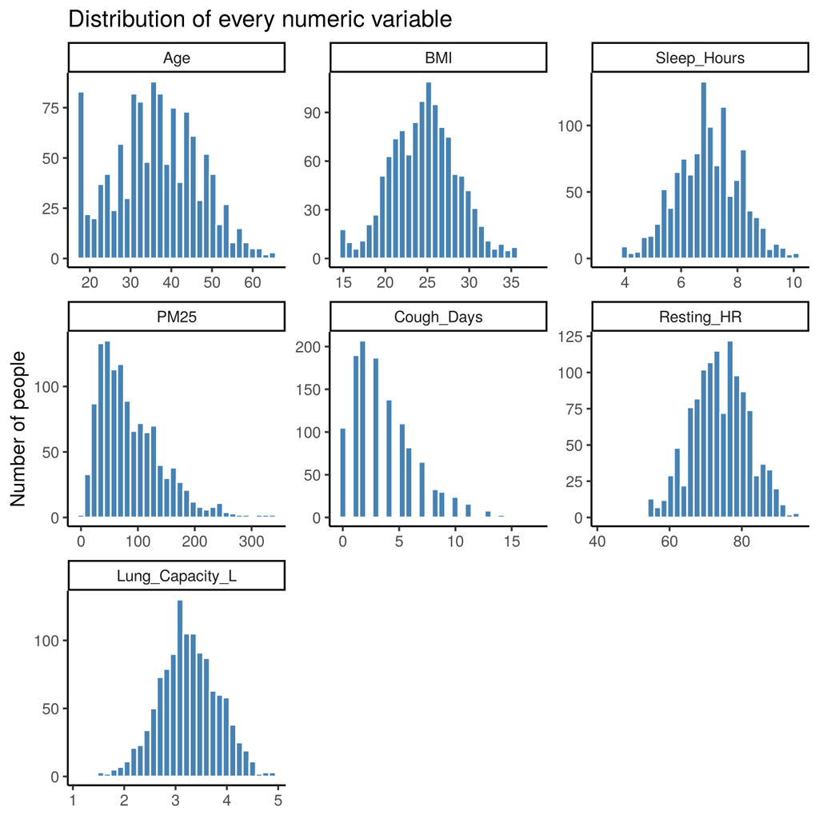

```r
long_num <- stack(d[num_vars])                       # one column of values, one of variable names
ggplot(long_num, aes(x = values)) +
  geom_histogram(bins = 30, fill = "steelblue", colour = "white") +
  facet_wrap(~ ind, scales = "free", ncol = 3) +
  labs(title = "Distribution of every numeric variable", x = NULL, y = "Number of people")
```

Age, BMI, sleep, heart rate and lung capacity look roughly bell-shaped. `PM25` and `Cough_Days` have a long right tail.

## 6.2 Categorical variables

```r
cat_vars <- c("Zone", "Sex", "Smoker", "Exercise_Level", "Mask_Use", "Respiratory_Illness")
for (v in cat_vars) {
  cat("\n", v, "\n")
  print(round(100 * prop.table(table(d[[v]])), 1))   # percent of people in each level
}
```

```
##
##  Zone
##
##        Park Residential Traffic_Hub  Industrial
##        21.9        29.1        29.9        19.1
##
##  Sex
##
## Female   Male
##   49.2   50.8
##
##  Smoker
##
##   No  Yes
## 82.8 17.2
##
##  Exercise_Level
##
##      Low Moderate     High
##     35.8     40.3     23.9
##
##  Mask_Use
##
##     Never Sometimes    Always
##      44.8      33.1      22.1
##
##  Respiratory_Illness
##
##   No  Yes
## 81.8 18.2
```

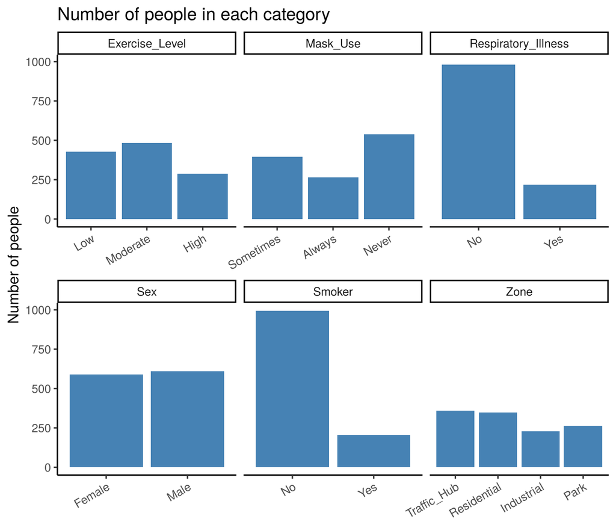

```r
cat_long <- data.frame(Variable = rep(cat_vars, each = nrow(d)),
                       Level = unlist(lapply(d[cat_vars], as.character)))
cat_long$Level <- factor(cat_long$Level, levels = unique(cat_long$Level))
ggplot(cat_long, aes(x = Level)) +
  geom_bar(fill = "steelblue") +
  facet_wrap(~ Variable, scales = "free_x", ncol = 3) +
  labs(title = "Number of people in each category", x = NULL, y = "Number of people") +
  theme(axis.text.x = element_text(angle = 30, hjust = 1))
```

- **Smokers** are 17.2% of the people, so smoking is a minority group.
- **Respiratory illness** affected 18.2% of the people. The outcome is not rare, but the “Yes” group is smaller than the “No” group.
- The four zones have different sizes; the largest groups are Traffic_Hub and Residential.

# 7 Is the data normal? Skewness and transformation

Many tests (t-test, ANOVA, Pearson correlation) work best when the variable is roughly **bell-shaped**. We check this in two ways: the Shapiro-Wilk test (H0: the data are normal) and a QQ plot (points on the line = normal).

```r
shapiro_table <- data.frame(Variable = num_vars,
  W = sapply(d[num_vars], function(x) shapiro.test(x[!is.na(x)])$statistic),
  p_value = sapply(d[num_vars], function(x) shapiro.test(x[!is.na(x)])$p.value),
  Skewness = sapply(d[num_vars], skew), row.names = NULL)
shapiro_table$p_value <- ifelse(shapiro_table$p_value < 0.001, "< 0.001", sprintf("%.3f", as.numeric(shapiro_table$p_value)))
knitr::kable(shapiro_table, digits = 3)
```

| Variable | W | p_value | Skewness |
| --- | --- | --- | --- |
| Age | 0.983 | < 0.001 | 0.084 |
| BMI | 0.997 | 0.017 | 0.033 |
| Sleep_Hours | 0.998 | 0.133 | -0.047 |
| PM25 | 0.912 | < 0.001 | 1.198 |
| Cough_Days | 0.912 | < 0.001 | 1.061 |
| Resting_HR | 0.996 | 0.008 | -0.099 |
| Lung_Capacity_L | 0.998 | 0.195 | -0.058 |

A common fix for right-skewed data is the **log transformation**:

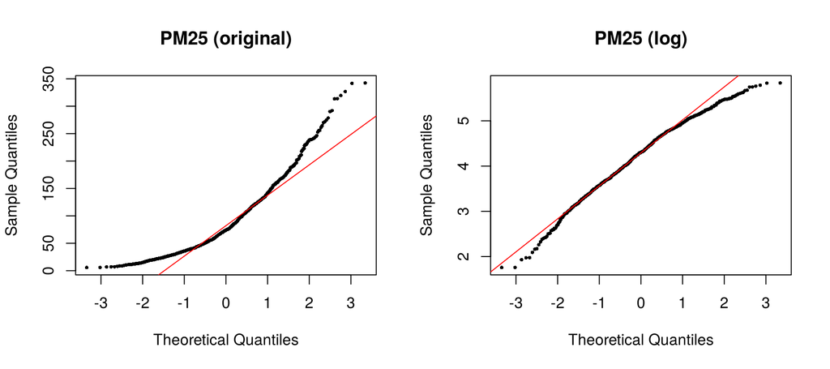

```r
d$log_PM25 <- log(d$PM25)

par(mfrow = c(1, 2))
qqnorm(d$PM25, main = "PM25 (original)", pch = 16, cex = 0.5); qqline(d$PM25, col = "red")
qqnorm(d$log_PM25, main = "PM25 (log)", pch = 16, cex = 0.5); qqline(d$log_PM25, col = "red")
```

```r
par(mfrow = c(1, 1))
```

The skewness drops from **1.20** (original) to **-0.44** (log). The log scale is much closer to a bell shape. For `PM25` we will either use tests that do not need normality (Wilcoxon, Kruskal-Wallis, Spearman) or the log version.

# 8 Comparing groups on a number

## 8.1 Two groups: t-test and Wilcoxon test

**Question.** Do the average values differ between two groups? **H0:** the two group means are equal. **H1:** they are different.

We use the Welch t-test (it does not assume equal spread in both groups). Cohen’s d is the effect size: about 0.2 is small, 0.5 medium, 0.8 large.

```r
pairs2 <- data.frame(
  y = c("Sleep_Hours", "BMI", "Lung_Capacity_L", "Lung_Capacity_L", "Resting_HR"),
  g = c("Sex",         "Sex", "Smoker",          "Sex",             "Smoker"),
  stringsAsFactors = FALSE)

two_group_tests <- do.call(rbind, lapply(seq_len(nrow(pairs2)), function(i) {
  y <- pairs2$y[i]; g <- pairs2$g[i]
  tt <- t.test(d[[y]] ~ d[[g]])                        # Welch t-test
  data.frame(Outcome = y, Groups = paste(levels(d[[g]]), collapse = " vs "),
             Mean_1 = unname(tt$estimate[1]), Mean_2 = unname(tt$estimate[2]),
             t = unname(tt$statistic), df = unname(tt$parameter),
             p = tt$p.value, Cohens_d = abs(cohens_d(d[[y]], d[[g]])))
}))
show <- two_group_tests
show$p <- pfmt(show$p)
knitr::kable(show, digits = 2, row.names = FALSE)
```

| Outcome | Groups | Mean_1 | Mean_2 | t | df | p | Cohens_d |
| --- | --- | --- | --- | --- | --- | --- | --- |
| Sleep_Hours | Female vs Male | 6.92 | 6.98 | -0.90 | 1174.99 | 0.370 | 0.05 |
| BMI | Female vs Male | 24.67 | 24.56 | 0.50 | 1190.69 | 0.619 | 0.03 |
| Lung_Capacity_L | No vs Yes | 3.26 | 3.21 | 1.29 | 328.08 | 0.197 | 0.09 |
| Lung_Capacity_L | Female vs Male | 2.93 | 3.56 | -22.76 | 1197.94 | < 0.001 | 1.31 |
| Resting_HR | No vs Yes | 74.12 | 73.51 | 1.01 | 292.79 | 0.312 | 0.08 |

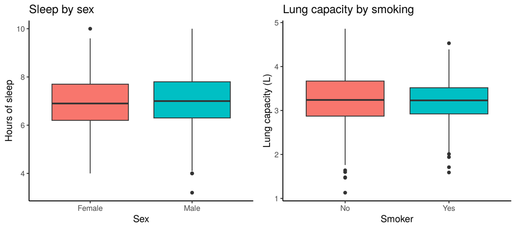

```r
p1 <- ggplot(d, aes(Sex, Sleep_Hours, fill = Sex)) + geom_boxplot(show.legend = FALSE) +
  labs(title = "Sleep by sex", y = "Hours of sleep")
p2 <- ggplot(d, aes(Smoker, Lung_Capacity_L, fill = Smoker)) + geom_boxplot(show.legend = FALSE) +
  labs(title = "Lung capacity by smoking", y = "Lung capacity (L)")
gridExtra_ok <- requireNamespace("gridExtra", quietly = TRUE)
if (gridExtra_ok) gridExtra::grid.arrange(p1, p2, ncol = 2) else { print(p1); print(p2) }
```

**Interpretation.**

- **Sleep and sex:** men sleep 6.98 hours and women 6.92 hours on average. The difference is **not significant** (p = 0.370, d = 0.05). Men and women sleep about the same.
- **Lung capacity and smoking:** non-smokers have 3.26 L and smokers 3.21 L. The difference is **not significant** (p = 0.197, d = 0.09).
- **A surprise worth noticing:** smoking damages lungs, yet the simple comparison shows almost no difference. The reason is that most smokers are men, and men naturally have bigger lungs, so the two effects hide each other. This is called **confounding**. The regression section below separates them.
- **Lung capacity and sex:** men have a larger lung capacity than women (3.56 vs 2.93 L, p < 0.001). This is normal body biology and we must remember it when we build models later.
- **BMI and sex:** not significant (p = 0.619).
- **Resting heart rate and smoking:** not significant (p = 0.312).

For skewed variables (`PM25`, `Cough_Days`) the median is a better summary, so we use the **Wilcoxon rank-sum test** (also called the Mann-Whitney test). H0: the two groups have the same distribution.

```r
w_pm_ill  <- wilcox.test(PM25 ~ Respiratory_Illness, data = d, exact = FALSE)
w_cough_s <- wilcox.test(Cough_Days ~ Smoker, data = d, exact = FALSE)

wilcox_table <- data.frame(
  Outcome = c("PM25", "Cough_Days"),
  Groups  = c("Illness: No vs Yes", "Smoker: No vs Yes"),
  Median_1 = c(median(d$PM25[d$Respiratory_Illness == "No"]), median(d$Cough_Days[d$Smoker == "No"])),
  Median_2 = c(median(d$PM25[d$Respiratory_Illness == "Yes"]), median(d$Cough_Days[d$Smoker == "Yes"])),
  p = pfmt(c(w_pm_ill$p.value, w_cough_s$p.value)))
knitr::kable(wilcox_table, digits = 1)
```

| Outcome | Groups | Median_1 | Median_2 | p |
| --- | --- | --- | --- | --- |
| PM25 | Illness: No vs Yes | 69.2 | 115.4 | < 0.001 |
| Cough_Days | Smoker: No vs Yes | 3.0 | 5.0 | < 0.001 |

People who had a respiratory illness live with higher dust levels (median 115.40 vs 69.20 micrograms per cubic metre, p < 0.001). Smokers cough on more days (median 5 vs 3, p < 0.001).

## 8.2 Three or more groups: ANOVA and Kruskal-Wallis

**Question.** Does lung capacity differ between the four zones? **H0:** all four zone means are equal. **H1:** at least one zone is different.

```r
aov_zone <- aov(Lung_Capacity_L ~ Zone, data = d)
an <- summary(aov_zone)[[1]]
F_zone <- an[["F value"]][1]; p_zone <- an[["Pr(>F)"]][1]
eta2_zone <- an[["Sum Sq"]][1] / sum(an[["Sum Sq"]])           # effect size
summary(aov_zone)
```

```
##               Df Sum Sq Mean Sq F value   Pr(>F)
## Zone           3   19.8   6.614   21.26 2.03e-13 ***
## Residuals   1196  372.1   0.311
## ---
## Signif. codes:  0 '***' 0.001 '**' 0.01 '*' 0.05 '.' 0.1 ' ' 1
```

```r
zone_means <- tapply(d$Lung_Capacity_L, d$Zone, mean)
round(zone_means, 2)
```

```
##        Park Residential Traffic_Hub  Industrial
##        3.43        3.32        3.18        3.06
```

```r
tuk <- TukeyHSD(aov_zone)$Zone                                  # which zones differ?
knitr::kable(round(tuk, 3))
```

|  | diff | lwr | upr | p adj |
| --- | --- | --- | --- | --- |
| Residential-Park | -0.113 | -0.230 | 0.004 | 0.064 |
| Traffic_Hub-Park | -0.249 | -0.365 | -0.132 | 0.000 |
| Industrial-Park | -0.368 | -0.497 | -0.238 | 0.000 |
| Traffic_Hub-Residential | -0.136 | -0.244 | -0.028 | 0.007 |
| Industrial-Residential | -0.255 | -0.377 | -0.133 | 0.000 |
| Industrial-Traffic_Hub | -0.119 | -0.240 | 0.002 | 0.057 |

```r
shapiro.test(residuals(aov_zone))      # are the residuals normal?
```

```
##
##  Shapiro-Wilk normality test
##
## data:  residuals(aov_zone)
## W = 0.99891, p-value = 0.6965
```

```r
bartlett.test(Lung_Capacity_L ~ Zone, data = d)   # equal variances?
```

```
##
##  Bartlett test of homogeneity of variances
##
## data:  Lung_Capacity_L by Zone
## Bartlett's K-squared = 2.082, df = 3, p-value = 0.5556
```

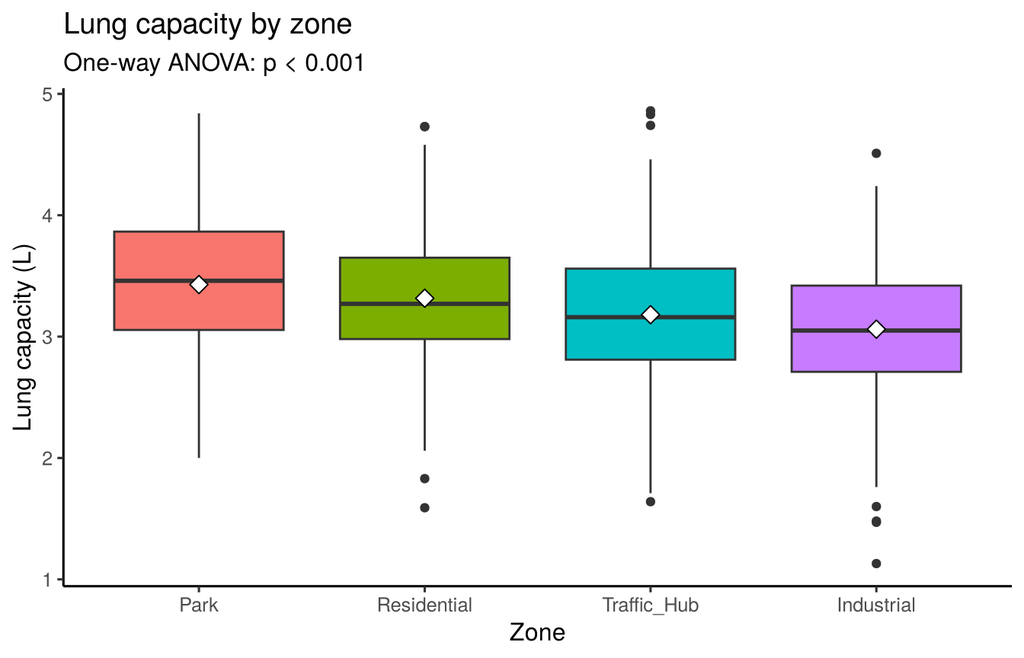

```r
ggplot(d, aes(Zone, Lung_Capacity_L, fill = Zone)) +
  geom_boxplot(show.legend = FALSE) +
  stat_summary(fun = mean, geom = "point", shape = 23, size = 3, fill = "white") +
  labs(title = "Lung capacity by zone", subtitle = paste("One-way ANOVA: p", ifelse(p_zone < 0.001, "< 0.001", paste("=", pfmt(p_zone)))),
       y = "Lung capacity (L)")
```

**Interpretation.** Lung capacity differs between zones (F = 21.26, p < 0.001). The zone explains about **5.1%** of the variation in lung capacity (eta-squared = 0.05), which is a small-to-medium effect: zone matters, but age, sex and smoking matter too. The **Industrial** zone has the lowest average (3.06 L) and **Park** the highest (3.43 L). Tukey’s test shows which pairs differ: in the table, a pair with adjusted p (“p adj”) below 0.05 is a real difference. The residuals are close to normal and the variances are similar, so ANOVA is a fair choice.

**Dust itself differs by zone too.** Because `PM25` is skewed, we use the Kruskal-Wallis test and pairwise Wilcoxon tests with Holm correction.

```r
kw_pm <- kruskal.test(PM25 ~ Zone, data = d)
kw_pm
```

```
##
##  Kruskal-Wallis rank sum test
##
## data:  PM25 by Zone
## Kruskal-Wallis chi-squared = 500.71, df = 3, p-value < 2.2e-16
```

```r
pairwise.wilcox.test(d$PM25, d$Zone, p.adjust.method = "holm", exact = FALSE)
```

```
##
##  Pairwise comparisons using Wilcoxon rank sum test with continuity correction
##
## data:  d$PM25 and d$Zone
##
##             Park    Residential Traffic_Hub
## Residential < 2e-16 -           -
## Traffic_Hub < 2e-16 < 2e-16     -
## Industrial  < 2e-16 < 2e-16     2.9e-09
##
## P value adjustment method: holm
```

```r
round(tapply(d$PM25, d$Zone, median), 1)
```

```
##        Park Residential Traffic_Hub  Industrial
##        37.7        66.0       104.0       130.9
```

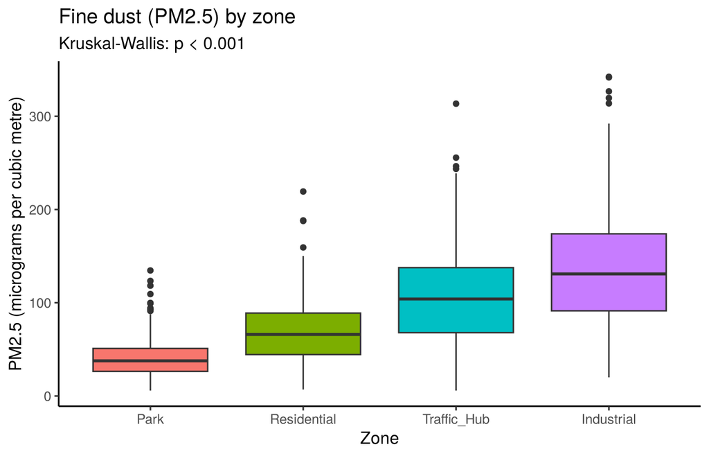

```r
ggplot(d, aes(Zone, PM25, fill = Zone)) +
  geom_boxplot(show.legend = FALSE) +
  labs(title = "Fine dust (PM2.5) by zone", subtitle = paste("Kruskal-Wallis: p", ifelse(kw_pm$p.value < 0.001, "< 0.001", paste("=", pfmt(kw_pm$p.value)))),
       y = "PM2.5 (micrograms per cubic metre)")
```

The dust level is clearly different between zones (p < 0.001). The Industrial zone has the highest median dust (130.9), the Park zone the lowest (37.7).

**Does exercise lower the resting heart rate?** Exercise level is an ordered category with three levels.

```r
aov_hr <- aov(Resting_HR ~ Exercise_Level, data = d)
an_hr <- summary(aov_hr)[[1]]
p_hr <- an_hr[["Pr(>F)"]][1]
summary(aov_hr)
```

```
##                  Df Sum Sq Mean Sq F value Pr(>F)
## Exercise_Level    2  12752    6376   129.8 <2e-16 ***
## Residuals      1197  58776      49
## ---
## Signif. codes:  0 '***' 0.001 '**' 0.01 '*' 0.05 '.' 0.1 ' ' 1
```

```r
hr_means <- tapply(d$Resting_HR, d$Exercise_Level, mean)
round(hr_means, 1)
```

```
##      Low Moderate     High
##     77.9     73.3     69.4
```

```r
round(TukeyHSD(aov_hr)$Exercise_Level, 3)
```

```
##                 diff    lwr    upr p adj
## Moderate-Low  -4.567 -5.657 -3.477     0
## High-Low      -8.477 -9.731 -7.223     0
## High-Moderate -3.910 -5.135 -2.685     0
```

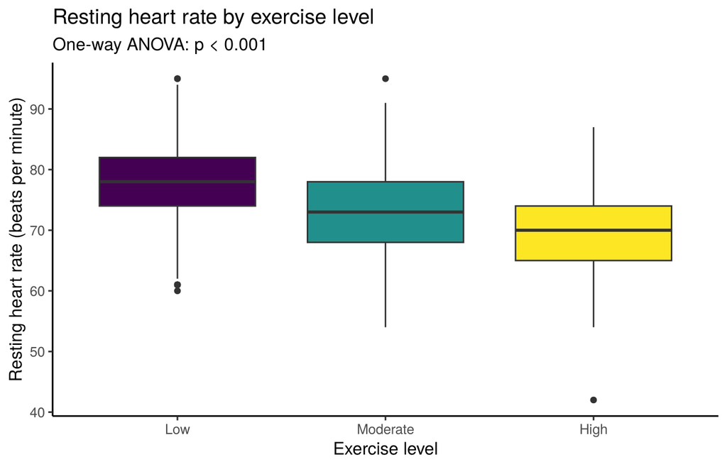

```r
ggplot(d, aes(Exercise_Level, Resting_HR, fill = Exercise_Level)) +
  geom_boxplot(show.legend = FALSE) +
  labs(title = "Resting heart rate by exercise level",
       subtitle = paste("One-way ANOVA: p", ifelse(p_hr < 0.001, "< 0.001", paste("=", pfmt(p_hr)))),
       x = "Exercise level", y = "Resting heart rate (beats per minute)")
```

Yes. The more people exercise, the lower the resting heart rate: 77.9 (Low), 73.3 (Moderate) and 69.4 (High) beats per minute (p < 0.001). The Tukey table shows that all three pairs differ.

# 9 Comparing categories

## 9.1 Are two categories linked? The chi-square test

**H0:** the two variables are independent (not linked). **H1:** they are linked. The test needs a **table of counts**. Cramer’s V is the effect size (about 0.1 small, 0.3 medium, 0.5 large).

### 9.1.1 Smoking and respiratory illness

```r
tab_si <- table(d$Smoker, d$Respiratory_Illness)
tab_si
```

```
##
##        No Yes
##   No  839 155
##   Yes 142  64
```

```r
round(100 * prop.table(tab_si, 1), 1)         # percent of each smoking group who were ill
```

```
##
##         No  Yes
##   No  84.4 15.6
##   Yes 68.9 31.1
```

```r
chi_si <- chisq.test(tab_si)                  # 2 x 2 table: Yates correction is used
chi_si
```

```
##
##  Pearson's Chi-squared test with Yates' continuity correction
##
## data:  tab_si
## X-squared = 26.36, df = 1, p-value = 2.834e-07
```

```r
fisher_si <- fisher.test(tab_si)              # also gives an odds ratio
fisher_si$estimate; fisher_si$conf.int
```

```
## odds ratio
##   2.437458
```

```
## [1] 1.702262 3.470290
## attr(,"conf.level")
## [1] 0.95
```

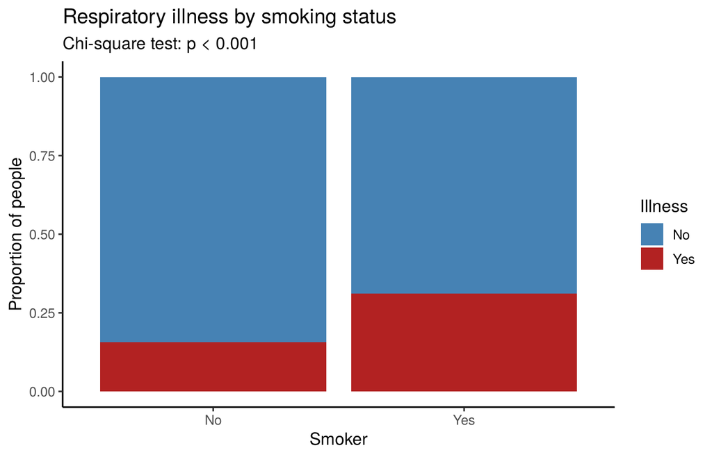

```r
V_si <- cramers_v(tab_si)

ggplot(d, aes(Smoker, fill = Respiratory_Illness)) +
  geom_bar(position = "fill") +
  scale_fill_manual(values = c(No = "steelblue", Yes = "firebrick")) +
  labs(title = "Respiratory illness by smoking status",
       subtitle = paste("Chi-square test: p", ifelse(chi_si$p.value < 0.001, "< 0.001", paste("=", pfmt(chi_si$p.value)))),
       y = "Proportion of people", fill = "Illness")
```

Among non-smokers 15.6% had a respiratory illness, compared with 31.1% among smokers. The link is **significant** (chi-square = 26.36, p < 0.001, Cramer’s V = 0.15). The odds ratio is **2.44** (95% CI 1.70 to 3.47): smokers have about 2.44 times the odds of illness.

### 9.1.2 Zone and respiratory illness

```r
tab_zi <- table(d$Zone, d$Respiratory_Illness)
round(100 * prop.table(tab_zi, 1), 1)
```

```
##
##                 No  Yes
##   Park        87.5 12.5
##   Residential 86.2 13.8
##   Traffic_Hub 81.3 18.7
##   Industrial  69.0 31.0
```

```r
chi_zi <- chisq.test(tab_zi)
chi_zi
```

```
##
##  Pearson's Chi-squared test
##
## data:  tab_zi
## X-squared = 35.472, df = 3, p-value = 9.683e-08
```

```r
round(chi_zi$stdres, 2)        # standardised residuals: beyond +/-2 = this cell drives the result
```

```
##
##                  No   Yes
##   Park         2.71 -2.71
##   Residential  2.58 -2.58
##   Traffic_Hub -0.24  0.24
##   Industrial  -5.55  5.55
```

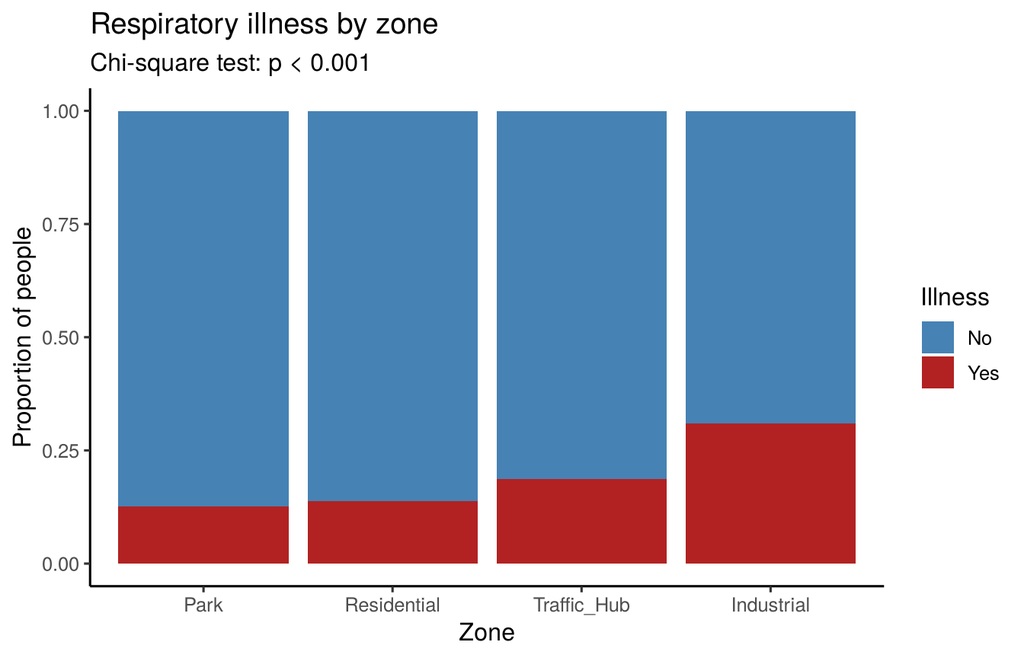

```r
V_zi <- cramers_v(tab_zi)

ggplot(d, aes(Zone, fill = Respiratory_Illness)) +
  geom_bar(position = "fill") +
  scale_fill_manual(values = c(No = "steelblue", Yes = "firebrick")) +
  labs(title = "Respiratory illness by zone",
       subtitle = paste("Chi-square test: p", ifelse(chi_zi$p.value < 0.001, "< 0.001", paste("=", pfmt(chi_zi$p.value)))),
       y = "Proportion of people", fill = "Illness")
```

Illness is significant linked to the zone (chi-square = 35.47, df = 3, p < 0.001, V = 0.17). The share of ill people is highest in the **Industrial** zone (31%) and lowest in the **Park** zone (12.5%).

### 9.1.3 Sex and smoking (a warning about confounding)

```r
tab_ss <- table(d$Sex, d$Smoker)
round(100 * prop.table(tab_ss, 1), 1)
```

```
##
##            No  Yes
##   Female 94.6  5.4
##   Male   71.5 28.5
```

```r
chi_ss <- chisq.test(tab_ss)
chi_ss
```

```
##
##  Pearson's Chi-squared test with Yates' continuity correction
##
## data:  tab_ss
## X-squared = 110.94, df = 1, p-value < 2.2e-16
```

```r
V_ss <- cramers_v(tab_ss)
```

### 9.1.4 Mask use and dust level

```r
tab_md <- table(d$PM25_Level, d$Mask_Use)
tab_md
```

```
##
##                    Never Sometimes Always
##   Low (<50)          196       111     57
##   Moderate (50-99)   232       126     61
##   High (100-149)      64       102     87
##   Very high (150+)    46        58     60
```

```r
chi_md <- chisq.test(tab_md)
round(chi_md$expected, 1)      # all expected counts should be 5 or more
```

```
##
##                    Never Sometimes Always
##   Low (<50)        163.2     120.4   80.4
##   Moderate (50-99) 187.9     138.6   92.5
##   High (100-149)   113.4      83.7   55.9
##   Very high (150+)  73.5      54.3   36.2
```

```r
chi_md
```

```
##
##  Pearson's Chi-squared test
##
## data:  tab_md
## X-squared = 105.47, df = 6, p-value < 2.2e-16
```

People living with more dust wear masks more often: the link is **significant** (p < 0.001, V = 0.21). All expected counts are at least 5, so the chi-square test is valid.

# 10 Relationships between numbers: correlation

**H0:** the correlation (r) is 0. **H1:** r is not 0. The value of r runs from -1 to +1: the sign gives the direction and the size gives the strength (about 0.1 weak, 0.3 moderate, 0.5 strong).

```r
cm <- cor(d[num_vars], use = "pairwise.complete.obs")      # Pearson correlations
round(cm, 2)
```

```
##                   Age   BMI Sleep_Hours  PM25 Cough_Days Resting_HR
## Age              1.00 -0.01       -0.01 -0.01       0.02      -0.01
## BMI             -0.01  1.00       -0.03  0.05       0.05       0.15
## Sleep_Hours     -0.01 -0.03        1.00  0.02       0.02      -0.03
## PM25            -0.01  0.05        0.02  1.00       0.63       0.03
## Cough_Days       0.02  0.05        0.02  0.63       1.00       0.02
## Resting_HR      -0.01  0.15       -0.03  0.03       0.02       1.00
## Lung_Capacity_L -0.34 -0.03        0.01 -0.41      -0.30      -0.01
##                 Lung_Capacity_L
## Age                       -0.34
## BMI                       -0.03
## Sleep_Hours                0.01
## PM25                      -0.41
## Cough_Days                -0.30
## Resting_HR                -0.01
## Lung_Capacity_L            1.00
```

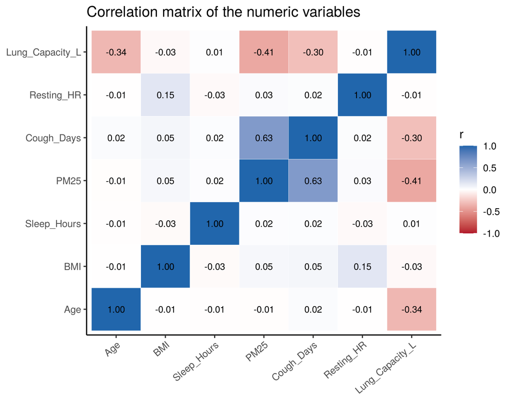

```r
cm_long <- as.data.frame(as.table(cm)); names(cm_long) <- c("Var1", "Var2", "r")
ggplot(cm_long, aes(Var1, Var2, fill = r)) +
  geom_tile(colour = "white") +
  geom_text(aes(label = sprintf("%.2f", r)), size = 3.2) +
  scale_fill_gradient2(low = "#B2182B", mid = "white", high = "#2166AC", limits = c(-1, 1)) +
  labs(title = "Correlation matrix of the numeric variables", x = NULL, y = NULL, fill = "r") +
  theme(axis.text.x = element_text(angle = 40, hjust = 1))
```

The strongest relationships (ignoring the diagonal):

```r
idx <- which(lower.tri(cm), arr.ind = TRUE)
pair_table <- data.frame(Variable_1 = rownames(cm)[idx[, 1]], Variable_2 = colnames(cm)[idx[, 2]],
                         r = cm[idx])
pair_table <- pair_table[order(-abs(pair_table$r)), ]
knitr::kable(head(pair_table, 6), digits = 2, row.names = FALSE)
```

| Variable_1 | Variable_2 | r |
| --- | --- | --- |
| Cough_Days | PM25 | 0.63 |
| Lung_Capacity_L | PM25 | -0.41 |
| Lung_Capacity_L | Age | -0.34 |
| Lung_Capacity_L | Cough_Days | -0.30 |
| Resting_HR | BMI | 0.15 |
| Cough_Days | BMI | 0.05 |

```r
ct_pm <- cor.test(d$PM25, d$Lung_Capacity_L)
ct_pm
```

```
##
##  Pearson's product-moment correlation
##
## data:  d$PM25 and d$Lung_Capacity_L
## t = -15.38, df = 1198, p-value < 2.2e-16
## alternative hypothesis: true correlation is not equal to 0
## 95 percent confidence interval:
##  -0.4522584 -0.3576908
## sample estimates:
##        cor
## -0.4060611
```

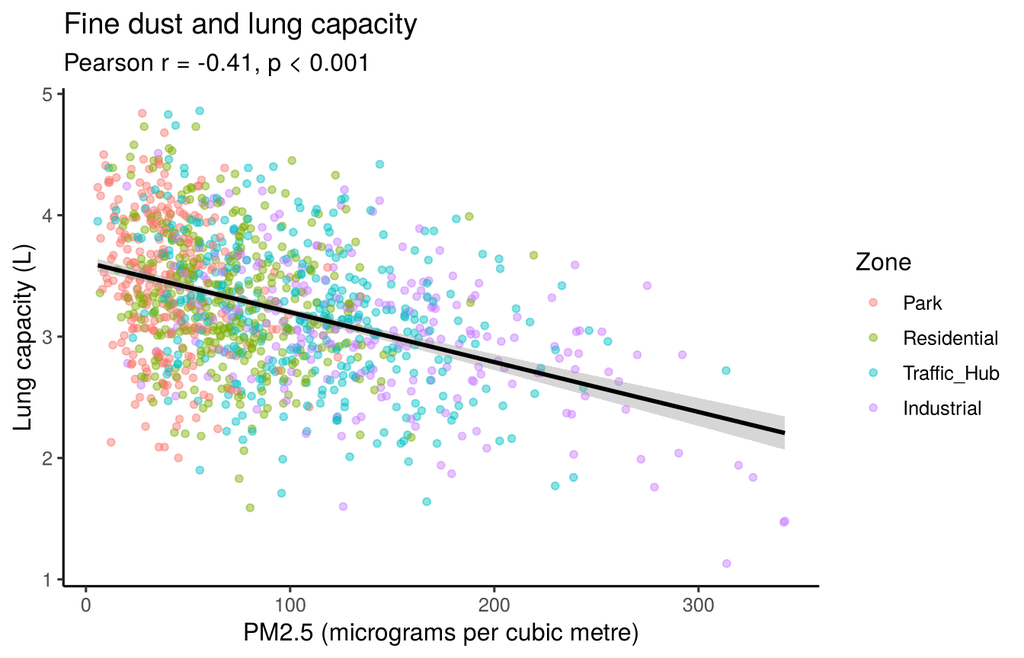

```r
ggplot(d, aes(PM25, Lung_Capacity_L, colour = Zone)) +
  geom_point(alpha = 0.45, size = 1.4) +
  geom_smooth(aes(group = 1), method = "lm", colour = "black") +
  labs(title = "Fine dust and lung capacity",
       subtitle = paste0("Pearson r = ", f2(ct_pm$estimate), ", p ", ifelse(ct_pm$p.value < 0.001, "< 0.001", paste("=", pfmt(ct_pm$p.value)))),
       x = "PM2.5 (micrograms per cubic metre)", y = "Lung capacity (L)")
```

**Interpretation.** More dust goes with smaller lungs: r = **-0.41** (95% CI -0.45 to -0.36, p < 0.001). That is a moderate negative relationship. Squaring r gives R-squared = 0.16: dust alone explains about 16% of the differences in lung capacity.

**Pearson or Spearman?** Spearman uses ranks and is safer for skewed variables such as `PM25` and `Cough_Days`.

```r
pairs_cor <- data.frame(x = c("PM25", "PM25", "Age"),
                        y = c("Lung_Capacity_L", "Cough_Days", "Lung_Capacity_L"),
                        stringsAsFactors = FALSE)
cor_compare <- do.call(rbind, lapply(seq_len(nrow(pairs_cor)), function(i) {
  pe <- cor.test(d[[pairs_cor$x[i]]], d[[pairs_cor$y[i]]])
  sp <- cor.test(d[[pairs_cor$x[i]]], d[[pairs_cor$y[i]]], method = "spearman", exact = FALSE)
  data.frame(X = pairs_cor$x[i], Y = pairs_cor$y[i], Pearson_r = unname(pe$estimate),
             Pearson_p = pfmt(pe$p.value), Spearman_rho = unname(sp$estimate),
             Spearman_p = pfmt(sp$p.value))
}))
knitr::kable(cor_compare, digits = 2)
```

| X | Y | Pearson_r | Pearson_p | Spearman_rho | Spearman_p |
| --- | --- | --- | --- | --- | --- |
| PM25 | Lung_Capacity_L | -0.41 | < 0.001 | -0.37 | < 0.001 |
| PM25 | Cough_Days | 0.63 | < 0.001 | 0.61 | < 0.001 |
| Age | Lung_Capacity_L | -0.34 | < 0.001 | -0.32 | < 0.001 |

Both methods agree. Dust is linked to smaller lungs and to more coughing days, and older people have smaller lungs. The Pearson and Spearman values are close, so the skew does not change the story.

**Is the dust effect only a zone effect?** Zones differ in dust *and* in many other ways. If dust really matters, the negative relationship should also appear **inside** each zone.

```r
within_zone <- do.call(rbind, lapply(levels(d$Zone), function(z) {
  s <- d[d$Zone == z, ]
  ct <- cor.test(s$PM25, s$Lung_Capacity_L)
  data.frame(Zone = z, n = nrow(s), r = unname(ct$estimate), p = pfmt(ct$p.value))
}))
knitr::kable(within_zone, digits = 2)
```

| Zone | n | r | p |
| --- | --- | --- | --- |
| Park | 263 | -0.24 | < 0.001 |
| Residential | 349 | -0.21 | < 0.001 |
| Traffic_Hub | 359 | -0.38 | < 0.001 |
| Industrial | 229 | -0.53 | < 0.001 |

Inside every zone the correlation is negative (from -0.53 to -0.21). So the link between dust and lung capacity is not just a difference between zones.

# 11 Two factors together: two-way ANOVA

Two-way ANOVA tests **three** things at once: the effect of factor A, the effect of factor B, and their **interaction** (does the effect of A change depending on B?).

```r
aov2 <- aov(Lung_Capacity_L ~ Sex * Smoker, data = d)
s2 <- summary(aov2)[[1]]
rownames(s2) <- trimws(rownames(s2))
s2
```

```
##              Df  Sum Sq Mean Sq  F value Pr(>F)
## Sex           1 118.210 118.210 552.6794 <2e-16 ***
## Smoker        1  17.689  17.689  82.7050 <2e-16 ***
## Sex:Smoker    1   0.249   0.249   1.1637 0.2809
## Residuals  1196 255.807   0.214
## ---
## Signif. codes:  0 '***' 0.001 '**' 0.01 '*' 0.05 '.' 0.1 ' ' 1
```

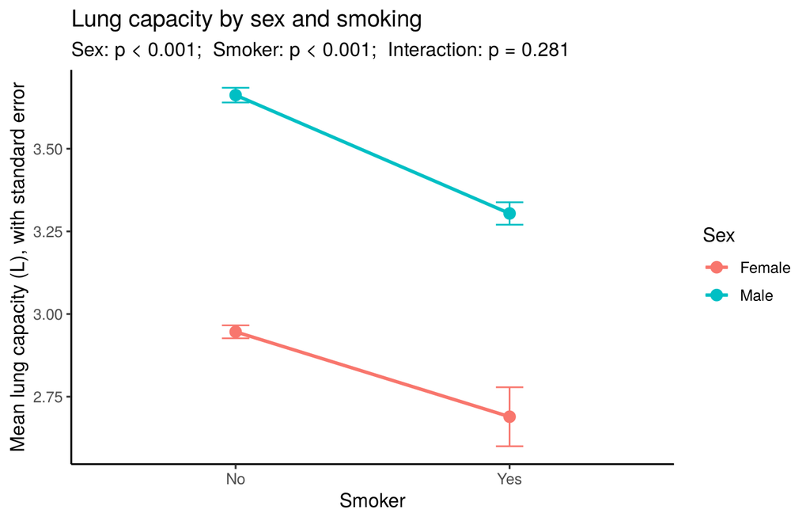

```r
p2 <- s2[["Pr(>F)"]][1:3]

ggplot(d, aes(Smoker, Lung_Capacity_L, colour = Sex, group = Sex)) +
  stat_summary(fun = mean, geom = "line", linewidth = 1) +
  stat_summary(fun.data = mean_se, geom = "errorbar", width = 0.1) +
  stat_summary(fun = mean, geom = "point", size = 3) +
  labs(title = "Lung capacity by sex and smoking",
       subtitle = paste0("Sex: p ", ifelse(p2[1] < 0.001, "< 0.001", paste("=", pfmt(p2[1]))),
                         ";  Smoker: p ", ifelse(p2[2] < 0.001, "< 0.001", paste("=", pfmt(p2[2]))),
                         ";  Interaction: p ", ifelse(p2[3] < 0.001, "< 0.001", paste("=", pfmt(p2[3])))),
       y = "Mean lung capacity (L), with standard error")
```

Both **sex** (p < 0.001) and **smoking** (p < 0.001) have an effect on lung capacity. The interaction is **not significant** (p 0.281): smoking lowers lung capacity by about the same amount in men and in women, so the two lines are parallel. Because the lines are parallel, we can describe the two effects separately.

A second look: does the zone effect depend on sex?

```r
aov3 <- aov(Lung_Capacity_L ~ Zone * Sex, data = d)
s3 <- summary(aov3)[[1]]; rownames(s3) <- trimws(rownames(s3))
s3
```

```
##             Df  Sum Sq Mean Sq  F value Pr(>F)
## Zone         3  19.842   6.614  30.6837 <2e-16 ***
## Sex          1 114.594 114.594 531.6115 <2e-16 ***
## Zone:Sex     3   0.573   0.191   0.8863 0.4476
## Residuals 1192 256.947   0.216
## ---
## Signif. codes:  0 '***' 0.001 '**' 0.01 '*' 0.05 '.' 0.1 ' ' 1
```

```r
p3 <- s3[["Pr(>F)"]][1:3]
```

Zone (p < 0.001) and sex (p < 0.001) both matter, and the zone x sex interaction is **not significant** (p 0.448). The zone effect is the same for men and women: dust hurts both sexes alike.

# 12 Did anything change over time?

The survey ran from 05 January to 04 April 2026. We check whether the months differ.

```r
table(d$Month)
```

```
##
## Jan Feb Mar Apr
## 384 354 401  61
```

```r
month_means <- aggregate(cbind(PM25, Cough_Days, Lung_Capacity_L) ~ Month, data = d, FUN = mean)
knitr::kable(month_means, digits = 2)
```

| Month | PM25 | Cough_Days | Lung_Capacity_L |
| --- | --- | --- | --- |
| Jan | 86.19 | 3.48 | 3.27 |
| Feb | 84.33 | 3.46 | 3.28 |
| Mar | 91.80 | 3.87 | 3.20 |
| Apr | 89.13 | 3.72 | 3.28 |

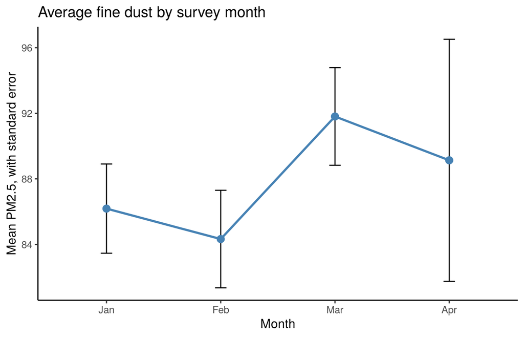

```r
kw_month <- kruskal.test(PM25 ~ Month, data = d)
p_month_lung <- summary(aov(Lung_Capacity_L ~ Month, data = d))[[1]][["Pr(>F)"]][1]

ggplot(d, aes(Month, PM25, group = 1)) +
  stat_summary(fun = mean, geom = "line", linewidth = 1, colour = "steelblue") +
  stat_summary(fun.data = mean_se, geom = "errorbar", width = 0.1) +
  stat_summary(fun = mean, geom = "point", size = 3, colour = "steelblue") +
  labs(title = "Average fine dust by survey month", y = "Mean PM2.5, with standard error")
```

Dust levels are similar across months (Kruskal-Wallis p = 0.364), and so is lung capacity (ANOVA p = 0.170). The survey months are comparable, so the survey date is not a worry for the rest of the analysis. A time effect would need a longer study.

# 13 Models that combine several variables

Tests compare two things at a time. Real life is tangled: lung capacity depends on dust, age, sex and smoking all at once. **Regression** looks at one variable while holding the others fixed.

## 13.1 Linear regression: what explains lung capacity?

The outcome is a number (`Lung_Capacity_L`), so we use `lm()`. Each coefficient is the change in lung capacity for a 1-unit increase in that variable, **with all other variables held constant**.

```r
m_simple <- lm(Lung_Capacity_L ~ PM25, data = d)       # dust alone
summary(m_simple)$coefficients
```

```
##                 Estimate   Std. Error   t value     Pr(>|t|)
## (Intercept)  3.611741870 0.0278642401 129.61925 0.000000e+00
## PM25        -0.004109582 0.0002672088 -15.37966 7.551659e-49
```

```r
m_lin <- lm(Lung_Capacity_L ~ PM25 + Age + Sex + Smoker + BMI, data = d)
sm <- summary(m_lin)
sm
```

```
##
## Call:
## lm(formula = Lung_Capacity_L ~ PM25 + Age + Sex + Smoker + BMI,
##     data = d)
##
## Residuals:
##      Min       1Q   Median       3Q      Max
## -1.18017 -0.22877  0.00553  0.23548  1.01981
##
## Coefficients:
##               Estimate Std. Error t value Pr(>|t|)
## (Intercept)  4.0145321  0.0742944   54.03   <2e-16 ***
## PM25        -0.0039975  0.0001779  -22.48   <2e-16 ***
## Age         -0.0199675  0.0009615  -20.77   <2e-16 ***
## SexMale      0.7123846  0.0210963   33.77   <2e-16 ***
## SmokerYes   -0.3370023  0.0279520  -12.06   <2e-16 ***
## BMI          0.0003316  0.0025473    0.13    0.896
## ---
## Signif. codes:  0 '***' 0.001 '**' 0.01 '*' 0.05 '.' 0.1 ' ' 1
##
## Residual standard error: 0.3473 on 1194 degrees of freedom
## Multiple R-squared:  0.6327, Adjusted R-squared:  0.6311
## F-statistic: 411.3 on 5 and 1194 DF,  p-value: < 2.2e-16
```

```r
coef_table <- cbind(Estimate = coef(m_lin), confint(m_lin), p = sm$coefficients[, 4])
coef_show <- as.data.frame(round(coef_table, 4))
coef_show$p <- pfmt(coef_table[, "p"])
knitr::kable(coef_show)
```

|  | Estimate | 2.5 % | 97.5 % | p |
| --- | --- | --- | --- | --- |
| (Intercept) | 4.0145 | 3.8688 | 4.1603 | < 0.001 |
| PM25 | -0.0040 | -0.0043 | -0.0036 | < 0.001 |
| Age | -0.0200 | -0.0219 | -0.0181 | < 0.001 |
| SexMale | 0.7124 | 0.6710 | 0.7538 | < 0.001 |
| SmokerYes | -0.3370 | -0.3918 | -0.2822 | < 0.001 |
| BMI | 0.0003 | -0.0047 | 0.0053 | 0.896 |

**Reading the table.**

- **Dust:** each extra 10 micrograms per cubic metre of PM2.5 lowers lung capacity by about **0.04 L**, after adjusting for age, sex, smoking and BMI (p < 0.001).
- **Age:** each extra year lowers lung capacity by about 0.020 L (p < 0.001).
- **Sex:** men have about 0.71 L more than women with the same age, dust and smoking (p < 0.001).
- **Smoking:** smokers have about 0.34 L less (p < 0.001).
- **BMI:** not significant (p 0.896).
- **Model fit:** R-squared = 0.63 and adjusted R-squared = 0.63: together these variables explain about **63%** of the differences in lung capacity. The typical prediction error is 0.35 L.

**Confounding in action.** The simple slope for dust was -0.0041 and the adjusted slope is -0.0040. They are close, so the dust effect stays after adjusting for the other variables.

**Checking the model.** Residuals should have no pattern (left plot) and be roughly normal (right plot).

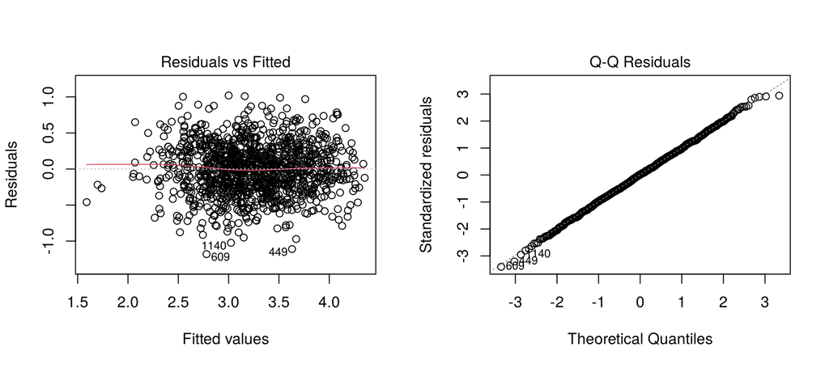

```r
par(mfrow = c(1, 2))
plot(m_lin, which = 1)      # residuals vs fitted values: should look like a random cloud
plot(m_lin, which = 2)      # QQ plot of residuals: should follow the line
```

```r
par(mfrow = c(1, 1))
```

The residual plot shows a random cloud around zero and the QQ plot follows the line, so the model assumptions are acceptable.

## 13.2 Logistic regression: what predicts respiratory illness?

The outcome is Yes / No, so we use `glm()` with `family = binomial`. The results are **odds ratios** (OR): OR above 1 means higher odds of illness, below 1 means lower odds, and 1 means no effect. We express dust in steps of 10 micrograms so the numbers are easy to read.

```r
m_log <- glm(Respiratory_Illness ~ I(PM25 / 10) + Smoker + Age + Sex, data = d, family = binomial)
summary(m_log)
```

```
##
## Call:
## glm(formula = Respiratory_Illness ~ I(PM25/10) + Smoker + Age +
##     Sex, family = binomial, data = d)
##
## Coefficients:
##               Estimate Std. Error z value Pr(>|z|)
## (Intercept) -2.7826326  0.3303926  -8.422  < 2e-16 ***
## I(PM25/10)   0.1139160  0.0129464   8.799  < 2e-16 ***
## SmokerYes    1.0550138  0.1962854   5.375 7.66e-08 ***
## Age         -0.0005428  0.0076067  -0.071    0.943
## SexMale     -0.0767801  0.1696428  -0.453    0.651
## ---
## Signif. codes:  0 '***' 0.001 '**' 0.01 '*' 0.05 '.' 0.1 ' ' 1
##
## (Dispersion parameter for binomial family taken to be 1)
##
##     Null deviance: 1140.4  on 1199  degrees of freedom
## Residual deviance: 1034.2  on 1195  degrees of freedom
## AIC: 1044.2
##
## Number of Fisher Scoring iterations: 4
```

```r
or_tab <- exp(cbind(OR = coef(m_log), confint.default(m_log)))[-1, ]    # drop the intercept
rownames(or_tab) <- c("PM25 (per +10)", "Smoker: Yes vs No", "Age (per +1 year)", "Sex: Male vs Female")
or_df <- data.frame(Predictor = rownames(or_tab), or_tab, p = pfmt(summary(m_log)$coefficients[-1, 4]),
                    row.names = NULL)
names(or_df)[2:4] <- c("OR", "Lower_95", "Upper_95")
knitr::kable(or_df, digits = 2)
```

| Predictor | OR | Lower_95 | Upper_95 | p |
| --- | --- | --- | --- | --- |
| PM25 (per +10) | 1.12 | 1.09 | 1.15 | < 0.001 |
| Smoker: Yes vs No | 2.87 | 1.95 | 4.22 | < 0.001 |
| Age (per +1 year) | 1.00 | 0.98 | 1.01 | 0.943 |
| Sex: Male vs Female | 0.93 | 0.66 | 1.29 | 0.651 |

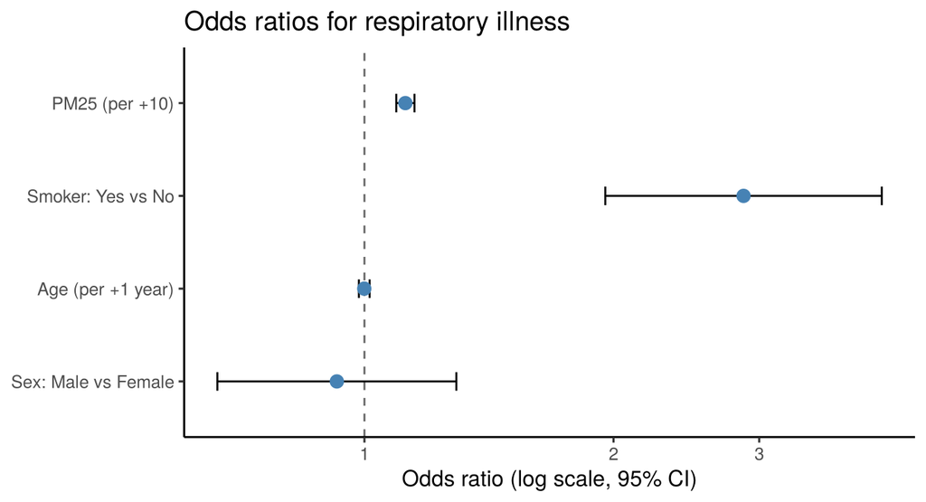

```r
or_df$Predictor <- factor(or_df$Predictor, levels = rev(or_df$Predictor))
ggplot(or_df, aes(OR, Predictor)) +
  geom_vline(xintercept = 1, linetype = "dashed", colour = "grey40") +
  geom_errorbarh(aes(xmin = Lower_95, xmax = Upper_95), height = 0.2) +
  geom_point(size = 3, colour = "steelblue") +
  scale_x_log10() +
  labs(title = "Odds ratios for respiratory illness", x = "Odds ratio (log scale, 95% CI)", y = NULL)
```

**Interpretation.**

- Each extra 10 micrograms of PM2.5 raises the odds of illness by about **12%** (OR = 1.12, p < 0.001).
- Smokers have **2.87 times** the odds of illness of non-smokers (p < 0.001), even after adjusting for dust, age and sex.
- Age: not significant (OR = 1.00, p 0.943). Sex: not significant (OR = 0.93, p 0.651).

**How good are the predictions?** We use the area under the ROC curve (AUC): 0.5 = guessing, 1 = perfect.

```r
d$p_hat <- predict(m_log, type = "response")            # predicted probability of illness
y <- d$Respiratory_Illness == "Yes"
n1 <- sum(y); n0 <- sum(!y)
auc <- (sum(rank(d$p_hat)[y]) - n1 * (n1 + 1) / 2) / (n1 * n0)    # AUC from ranks

pred_class <- factor(ifelse(d$p_hat > 0.5, "Yes", "No"), levels = c("No", "Yes"))
conf <- table(Predicted = pred_class, Observed = d$Respiratory_Illness)
conf
```

```
##          Observed
## Predicted  No Yes
##       No  965 201
##       Yes  16  18
```

```r
accuracy <- sum(diag(conf)) / sum(conf)
baseline <- max(prop.table(table(d$Respiratory_Illness)))   # always guessing "No"
```

The AUC is **0.71**, which means the model separates ill from healthy people reasonably well. At a cut-off of 0.5 the accuracy is 81.9%, and always guessing “No” would give 81.8%. Accuracy alone is a weak measure when one group is much bigger, and that is why we look at the AUC.

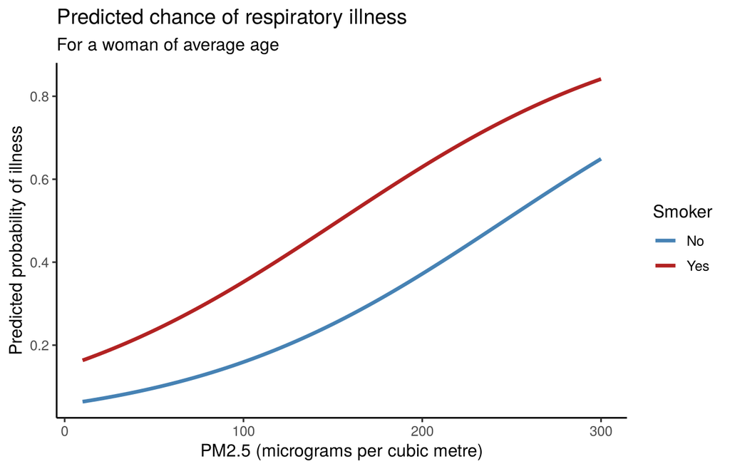

```r
newdat <- expand.grid(PM25 = seq(10, 300, length.out = 100), Smoker = c("No", "Yes"),
                      Age = mean(d$Age), Sex = "Female")
newdat$Smoker <- factor(newdat$Smoker, levels = c("No", "Yes"))
newdat$Sex    <- factor(newdat$Sex, levels = c("Female", "Male"))
newdat$prob   <- predict(m_log, newdat, type = "response")

ggplot(newdat, aes(PM25, prob, colour = Smoker)) +
  geom_line(linewidth = 1.2) +
  scale_colour_manual(values = c(No = "steelblue", Yes = "firebrick")) +
  labs(title = "Predicted chance of respiratory illness",
       subtitle = "For a woman of average age",
       x = "PM2.5 (micrograms per cubic metre)", y = "Predicted probability of illness")
```

## 13.3 Poisson regression: what explains the number of cough days?

`Cough_Days` is a **count** (0, 1, 2, …), so we use `glm()` with `family = poisson`. The results are **rate ratios**: a rate ratio of 1.10 means 10% more cough days.

```r
m_pois <- glm(Cough_Days ~ I(PM25 / 10) + Smoker, data = d, family = poisson)
rr <- exp(cbind(RR = coef(m_pois), confint.default(m_pois)))[-1, ]
rownames(rr) <- c("PM25 (per +10)", "Smoker: Yes vs No")
knitr::kable(round(rr, 2))
```

|  | RR | 2.5 % | 97.5 % |
| --- | --- | --- | --- |
| PM25 (per +10) | 1.07 | 1.07 | 1.08 |
| Smoker: Yes vs No | 1.92 | 1.79 | 2.05 |

```r
dispersion <- deviance(m_pois) / df.residual(m_pois)
```

Each extra 10 micrograms of PM2.5 means about **7% more** cough days, and smokers have about **1.92 times** as many cough days as non-smokers (p for both < 0.001). The dispersion ratio is 1.19. A value near 1 means the Poisson model fits well. This value is close to 1, so the Poisson model is a good choice here.

# 14 Summary of the findings

```r
summary_tab <- data.frame(
  Question = c(
    "Do men and women sleep different hours?",
    "Do smokers have different lung capacity?",
    "Does lung capacity differ between zones?",
    "Does dust (PM2.5) differ between zones?",
    "Does exercise change resting heart rate?",
    "Is smoking linked to respiratory illness?",
    "Is zone linked to respiratory illness?",
    "Is sex linked to smoking?",
    "Are dust and lung capacity correlated?",
    "Does the zone effect depend on sex?"),
  Test = c("Welch t-test", "Welch t-test", "One-way ANOVA", "Kruskal-Wallis", "One-way ANOVA",
           "Chi-square", "Chi-square", "Chi-square", "Pearson correlation", "Two-way ANOVA interaction"),
  p = c(two_group_tests$p[1], two_group_tests$p[3], p_zone, kw_pm$p.value, p_hr,
        chi_si$p.value, chi_zi$p.value, chi_ss$p.value, ct_pm$p.value, p3[3]))
summary_tab$Result <- ifelse(summary_tab$p < 0.05, "Significant", "Not significant")
summary_tab$p <- pfmt(summary_tab$p)
knitr::kable(summary_tab)
```

| Question | Test | p | Result |
| --- | --- | --- | --- |
| Do men and women sleep different hours? | Welch t-test | 0.370 | Not significant |
| Do smokers have different lung capacity? | Welch t-test | 0.197 | Not significant |
| Does lung capacity differ between zones? | One-way ANOVA | < 0.001 | Significant |
| Does dust (PM2.5) differ between zones? | Kruskal-Wallis | < 0.001 | Significant |
| Does exercise change resting heart rate? | One-way ANOVA | < 0.001 | Significant |
| Is smoking linked to respiratory illness? | Chi-square | < 0.001 | Significant |
| Is zone linked to respiratory illness? | Chi-square | < 0.001 | Significant |
| Is sex linked to smoking? | Chi-square | < 0.001 | Significant |
| Are dust and lung capacity correlated? | Pearson correlation | < 0.001 | Significant |
| Does the zone effect depend on sex? | Two-way ANOVA interaction | 0.448 | Not significant |

**Key findings**

1. **Dust and lungs.** More fine dust goes with smaller lung capacity (r = -0.41), and the link remains after adjusting for age, sex, smoking and BMI (about 0.04 L less per +10 micrograms of PM2.5).
2. **Place matters.** The Industrial zone has the highest dust and the lowest average lung capacity, and the Park zone the highest lung capacity.
3. **Smoking harms in several ways.** After adjusting for sex, smokers have smaller lungs (about 0.34 L), more cough days (1.92 times) and 2.87 times the odds of respiratory illness.
4. **Illness and dust.** Each extra 10 micrograms of PM2.5 raises the odds of respiratory illness by about 12%.
5. **Things that do not matter.** Men and women sleep the same number of hours. Not every comparison gives a significant result, and that is also a finding.
6. **Confounding.** Men smoke more than women, so sex and smoking must be studied together. Regression separates them.

**Limits of this analysis.** This is an observational survey, so we can show that variables are *linked*, but we cannot prove that dust *causes* smaller lungs. Other factors that were not measured (income, job, indoor air) could play a role. Many tests were run, so a few borderline p-values could be false alarms.

# 15 Practice tasks

1. Repeat the Welch t-test for `Resting_HR` by `Sex` and report the effect size.
2. Find which `BMI_Category` has the highest respiratory illness rate, and test it with a chi-square test.
3. Draw a box plot of `Cough_Days` by `Mask_Use`. Do mask-wearers cough less? Test it with Kruskal-Wallis.
4. Add `Exercise_Level` to the linear model for lung capacity. Does R-squared improve?
5. Use `Age_Group` instead of `Age` in the logistic model. What do the odds ratios say?